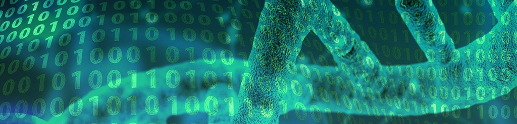

#### **Máster de Bioinformática y Bioestadística**

##### Análisis de datos ómicos: PEC 1

##### Dani Ibáñez 26-4-2021

### **DESCRIPCIÓN DEL ESTUDIO: Síndrome de Turner**

#### **Descripción general**

El síndrome de Turner és una patología descubierta por el propio endocrinólogo Henry Turner que afecta solo a mujeres y que se detecta, principalmente, por unos pliegues en el cuello en niñas pequeñas o recién nacidas y en un crecimiento que se para prematuramente quedando con estaturas claramente inferiores a la media. Esterilidad, extremidades hinchadas, genitales y mamas subdesarrolladas, son algunas otras características clínicas.

Aunque se describió esta patología en 1938, fue en 1959 cuando un grupo de científicos descubrieron la principal característica para su detección “sencilla”. Se trata de personas que solo tienen un cromosoma X completo, pudiendo tener parte del segundo o la mayoría con un solo cromosoma sexual X. Es por ello que se identifican como personas con 45 cromosomas (45X). Si el cromosoma X único o entero viene del padre hablaremos de genotipo o cariotipo 45Xp, y si procede de la madre hablaremos de genotipo o cariotipo 45Xm.

Parece demostrado que no es hereditario, pero a su vez se considera que la mayoría de incidencia es causada por el cromosoma X aportado por el padre, por lo que se considera que son patologías generadas o en el proceso de meiosis de los padres o en las primeras fases de multiplicación embrionaria. Esta segunda opción podría explicar por qué algunas mujeres presentan células con los dos cromosomas XX y otras células sin uno de ellos.

No hay un tratamiento específico definido, si bien, el principal problema que es la baja estatura responde a tratamientos de estimulación de hormona del crecimiento.

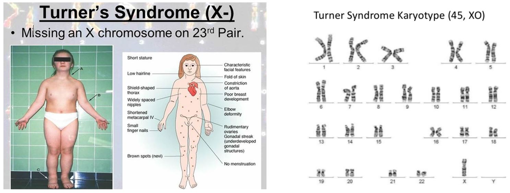

**Fuente: Página web healthjade.com**

#### **Descripción del estudio**

Al margen de los problemas de nacimiento, parece que existe predisposición de padecer enfermedades más graves como problemas cardiovasculares, diabetes o enfermedades de caracter autoinmune. Con este objetivo se realizan estudios de expresión génica comparando muestras de pacientes con esta patología.

En concreto, los científicos Cheng CM, Zhou J, Bondy C y otros, realizaron un análisis basado en 36 muestras distribuidas como sigue:

- 10 muestras de 10 mujeres con ambos cromosomas XX (“normales” 46,XX) que nos sirven de referencia.
- 16 muestras de 16 mujeres con un solo cromosoma X de procedencia materna 45,Xm
- 10 muestras de 10 mujeres con un solo cromosoma X de procedencia paterna 45,Xp

El experimento está realizado sobre microarray de affymetrix U133 versión 2.0 (GPL570) y se ha registrado en GEO con el repositorio GSE46687

Como ampliación de la información, el probe set U133 2.0 contiene un catálogo ampliado respecto la primera versión de U133. En este caso hablamos de 47.000 tránscritos distintos que se corresponden con 38.500 genes.

#### **Subset de 18 muestras para el estudio**

Para realizar el ejercicio de la PEC1, se ha extraído un subset de la muestra total de 36. En concreto se va a trabajar con una selección aleatoria de 6 muestras de cada uno de los 3 tipos, es decir 18 muestras, 6 XX (mujeres con los dos cromosomas X), 6 Xm (mujeres con un único cromosoma de origen materno) y 6 Xp (6 mujeres con un único cromosoma de origen paterno). Como se indica más abajo esta subselección aleatoria se ha realizado en base al número IDP de la UOC del alumno, en mi caso **IDP: 1083627**

#### **Documentación**

Para realizar el estudio he utilizado como guía la seguida por el Sr. Alex Sánchez en el estudio del caso GSE100924:

https://aspteaching.github.io/Omics_Data_Analysis-Case_Study_1-Microarrays/Case_Study_1-Microarrays_Analysis.html

Al final del documento se citan otras referencias usadas.

### **PREPARACIÓN DE ENTORNO DE TRABAJO**

#### **Carga de paquetes Bioconductor**

Para empezar vamos a instalar todos los paquetes necesarios para el estudio. La mayoría tienen relación con Biocondutor. Uno de los que tenemos que instalar es el feature data del microarray del estudio, en este caso el U133 plus 2. En concreto el paquete se llama “hgu133plus2.db”. Toda esta información se puede obtener de la página web de BIOCONDUCTOR:

https://bioconductor.org/packages/release/data/annotation/html/hgu133plus2.db.html

```r
# if (!requireNamespace("BiocManager", quietly = TRUE))
#     install.packages("BiocManager")
# BiocManager::install()

#if(!(require(knitr))) install.packages("knitr")
#if(!(require(colorspace))) install.packages("colorspace")
#if(!(require(gplots))) install.packages("gplots")
#if(!(require(ggplot2))) install.packages("ggplot2")
#if(!(require(ggrepel))) install.packages("ggrepel")
#if(!(require(htmlTable))) install.packages("htmlTable")
#if(!(require(prettydoc))) install.packages("prettydoc")
#if(!(require(devtools))) install.packages("devtools")
#if(!(require(BiocManager))) install.packages("BiocManager")

# install.packages("Rtools")
# BiocManager::install("oligo")
# BiocManager::install("arrayQualityMetrics")
# BiocManager::install("pvca")


# PAQUETES NECESARIOS PARA EL ANALISIS

# BiocManager::install("limma")
# BiocManager::install("genefilter")
# BiocManager::install("annotate")
# BiocManager::install("ReactomePA")
# BiocManager::install("reactome.db")
# BiocManager::install("ggnewscale")
# BiocManager::install("AnnotationDbi")
# BiocManager::install("hgu133plus2.db")
# BiocManager::install("org.Hs.eg.db")
```

#### **Creación del espacio de trabajo**

La gran cantidad de información nos “obliga” a estructurar la información en directorios. podemos seguir el convenio habitual en crear un directorio **data** y un directorio **results**. Además el proceso de workflow generará otros directorios que iremos viendo.

```r
setwd("C:/MASTER/OMICAS/ENTREGA PEC1")
if (!dir.exists("data")) {dir.create("data")}
if (!dir.exists("results")) {dir.create("results")}
```

#### **Subset de muestras**

Tal como he informado antes, para este estudio se nos indica trabajar con un subset de las 36 muestras originales. En concreto nos piden aplicar la función del enunciado usando nuestro número IDP.

En mi caso, con **IDP: 1083627**, las muestras seleccionadas son las siguientes:

```r
selectSamples<- function (myID){
 set.seed(myID)
 selected <- c(sample(1:10, 6),11, sample(12:26, 5), sample(27:36,6))
 selected <- sort(selected)
 }

samples_idp = selectSamples(1083627)
samples_idp
```

```
 [1]  1  2  3  8  9 10 11 13 17 18 23 25 27 28 29 30 33 35
```

A partir de aquí establecemos nuestro set de muestras personalizado con las 18 columnas concretas obtenidas. He cambiado el nombre de la columna de muestra **“sample_id”** y la del grupo es **“karyotype”**

Comprobamos cuales son y presentamos la tabla de los valores Phenodata:

##### **Subset de muestras seleccionadas para la PEC1 para IDP:1083627**

```r
targetsAll <-read.csv(file="./data/targetsAll.csv", row.names = 1, head=TRUE)
#row.names(targetsAll)
targets18 <- targetsAll[samples_idp,] # cogemos solo las columnas marcadas por el IDP
#length(targets18)
#row.names(targets18)
colnames(targets18)[1]<-"sample_id"
#colnames(targets18)
#class(targets18)
#rownames(targets18)
muestras <- targets18$sample_id

knitr::kable(targets18, booktabs = TRUE)
```

|  | sample_id | karyotype |
| --- | --- | --- |
| GSM1134016 | XX_rep1 | 46XX |
| GSM1134017 | XX_rep2 | 46XX |
| GSM1134018 | XX_rep3 | 46XX |
| GSM1134023 | XX_rep8 | 46XX |
| GSM1134024 | XX_rep9 | 46XX |
| GSM1134025 | XX_rep10 | 46XX |
| GSM1134026 | Xm_rep1 | 45Xm |
| GSM1134028 | Xm_rep3 | 45Xm |
| GSM1134032 | Xm_rep7 | 45Xm |
| GSM1134033 | Xm_rep8 | 45Xm |
| GSM1134038 | Xm_rep13 | 45Xm |
| GSM1134040 | Xm_rep15 | 45Xm |
| GSM1134042 | Xp_rep1 | 45Xp |
| GSM1134043 | Xp_rep2 | 45Xp |
| GSM1134044 | Xp_rep3 | 45Xp |
| GSM1134045 | Xp_rep4 | 45Xp |
| GSM1134048 | Xp_rep7 | 45Xp |
| GSM1134050 | Xp_rep9 | 45Xp |

### **CARGA DE DATOS DEL ESTUDIO**

#### **Lectura de los archivos CEL correspondientes a nuestra selección**

A partir del repositorio GSE en la página web de OMNIBUS:

https://www.ncbi.nlm.nih.gov/geo/query/acc.cgi?acc=gse46687

Hemos descargado manualmente todos los archivos CEL y he dejado en el disco solo los correspondientes a las 18 muestras seleccionadas. Este proceso lo he realizado manualmente.

Por otra parte he creado manualmente un archivo llamado **targets18.csv** que contiene solo los registros de las 18 muestras seleccionadas. Los campos de este archivo vienen separados por coma.

Una vez eliminados los 18 sobrantes, hemos descomprimido los archivos y ahora ya estamos en disposición de leerlos mediante las funciones **list.celfiles** , **read.AnnotatedDataFrame()** y **read.celfiles()**

Para ello cargamos las librerías **oligo** y **Biobase** y creamos dos variables esenciales a partir de este instante:

- **my.targets** es el archivo de las 18 muestras.Le vamos a cambiar los nombres de las variables colnames()
- **rawData** es el DataFrame en que hemos cargado los datos en bruto procedentes de los archivos CEL.

```r
library(oligo)
celFiles <- list.celfiles("./data", full.names = TRUE) # lee los archivos CEL del directorio /data
#celFiles
library(Biobase)
my.targets <-read.AnnotatedDataFrame(file.path("./data","targets18.csv"), header = TRUE, row.names = 1, sep=",")
my.targets
```

```
An object of class 'AnnotatedDataFrame'
  rowNames: "GSM1134016" "GSM1134017" ... "GSM1134050" (18 total)
  varLabels: X.title. X.karyotype.
  varMetadata: labelDescription
```

```r
#rownames(my.targets)
cat("variables de my.targets: ",colnames(my.targets))
```

```
variables de my.targets:  X.title. X.karyotype.
```

```r
colnames(my.targets) <- c("sample_id","karyotype")
cat("variables modificadas de my.targets: ",colnames(my.targets))
```

```
variables modificadas de my.targets:  sample_id karyotype
```

```r
rawData <- read.celfiles(celFiles, phenoData = my.targets)
```

```
Reading in : ./data/GSM1134016_EA04058_25073_H133+_F15.CEL
Reading in : ./data/GSM1134017_EA04058_25074_H133+_F16.CEL
Reading in : ./data/GSM1134018_EA04058_25075_H133+_F20.CEL
Reading in : ./data/GSM1134023_EA04058_25080_H133+_F43.CEL
Reading in : ./data/GSM1134024_EA04058_25081_H133+_F45.CEL
Reading in : ./data/GSM1134025_EA04058_25082_H133+_F52.CEL
Reading in : ./data/GSM1134026_EA04058_28124_H133+_TS208.CEL
Reading in : ./data/GSM1134028_EA04058_30434_H133+_TS258.CEL
Reading in : ./data/GSM1134032_EA04058_52892_H133+_TS279.CEL
Reading in : ./data/GSM1134033_EA04058_52893_H133+_TS236.CEL
Reading in : ./data/GSM1134038_EA04058_52899_H133+_TS221.CEL
Reading in : ./data/GSM1134040_EA04058_53538_H133+_TS290.CEL
Reading in : ./data/GSM1134042_EA04058_30426_H133+_TS168.CEL
Reading in : ./data/GSM1134043_EA04058_30427_H133+_TS79.CEL
Reading in : ./data/GSM1134044_EA04058_52884_H133+_TS11.CEL
Reading in : ./data/GSM1134045_EA04058_52885_H133+_TS120.CEL
Reading in : ./data/GSM1134048_EA04058_52888_H133+_TS241.CEL
Reading in : ./data/GSM1134050_EA04058_52891_H133+_TS315.CEL
```

```r
cat("Comprobamos Clase rawData: ",class(rawData))
```

```
Comprobamos Clase rawData:  ExpressionFeatureSet
```

```r
#rownames(pData(rawData))
#colnames(rawData)
#knitr::kable(pData(rawData), booktabs = TRUE, caption = 'Tabla phenotipo de rawData GSE46687')
#pData(rawData)
my.targets@data$sample_id->rownames(pData(rawData))
colnames(rawData) <-rownames(pData(rawData))

#muestras -> rownames(pData(rawData))
#colnames(rawData) <-rownames(pData(rawData))
#head(pData(rawData))
#rawData
#colnames(rawData)

cat("Comprobamos las dimensiones de los datos en rawData")
```

```
Comprobamos las dimensiones de los datos en rawData
```

```r
dim(exprs(rawData))
```

```
[1] 1354896      18
```

```r
cat("Comprobamos las primeras filas del rawData")
```

```
Comprobamos las primeras filas del rawData
```

```r
head(exprs(rawData)[,1:6],10) # primeras filas de las 8 primeras columnas
```

```
   "XX_rep1" "XX_rep2" "XX_rep3" "XX_rep8" "XX_rep9" "XX_rep10"
1         88       116       133       158       124        154
2       9954      7769      9658     10767      8026      11039
3        175       173       190       183       187        215
4      11354      8560     10681     10738     10564      11440
5        160       119       172       125       124        110
6        100       106       105       110       129        100
7      10122      8012     10307     10197      8770      11206
8        124       121       111       124       124        137
9       9548      7146      9474     10298      8291      10924
10       132       118       111       117       149        136
```

```r
cat("Comprobamos las últimas filas del rawData")
```

```
Comprobamos las últimas filas del rawData
```

```r
tail(exprs(rawData)[,13:18],10) # últimas filas de las 8 columnas restantes
```

```
        "Xp_rep1" "Xp_rep2" "Xp_rep3" "Xp_rep4" "Xp_rep7" "Xp_rep9"
1354887      3344      4620     11475     13856     12625     13246
1354888        84        61       279       391       346       378
1354889      3537      4611     11276     14069     13674     13187
1354890        59        74       260       405       391       385
1354891      3567      5098     11603     14664     14518     13363
1354892        58        55       256       266       305       312
1354893      3475      4702     11238     14918     13888     13579
1354894        90        69       334       355       347       525
1354895      3475      4583     11075     13999     13537     13241
1354896        63        67       279       296       372       387
```

### **PRIMERA MIRADA A LOS DATOS**

#### **Número de registros y valores**

Como observaciones a los datos del rawData comentamos los siguientes puntos:

- Estamos ante una matriz de casi **millón y medio** de registros. Está claro que son datos en bruto, pues no tenemos millón y medio de tránscritos.
- Nos hemos fijado en que la serie muestra un dato alto y otro bajo de forma sucesiva. Creemos que eso se debe a la **técnica del mismatch**, es decir, la técnica que ofrece en la lectura, una sonda que encaja con el tránscrito y otra donde se ha modificado el nucleótido central. Por lo tanto es lógico que en la primera encaje y en la segunda debe no encajar.
- Hemos modificado los nombres de las columnas ya que nos añade una x. un poco engorrosa.

Una vez hemos realizado la primera mirada sobre los datos en bruto, pasamos a plantear el estudio y a realizarlo.

### **PLANTEAMIENTO INICIAL DEL ESTUDIO Y PRIMERAS REFLEXIONES**

#### **Ampliando la información mediante getGEO()**

El archivo **targetsAll** que se nos ha proporcionado es muy escueto y no sé seguro si hay información adicional en el repositorio de Omnibus que nos ayude a realizar el estudio. Para ello buscaré en el **PhenoData** del repositorio GSE46687.

library(GEOquery)

-Turner <- getGEO(“GSE46687”,GSEMatrix=TRUE)

-str(pData)

-head(pData)

-NOTA: Se adjunta todo el código R utilizado.

He indicado las lineas justas para comprobar que el repositorio GSE46687 **no aporta información adicional**. Podría parecer que **gender** en el pData sería un dato importante pero todas las muestras son de mujeres como ya hemos explicado al inicio del estudio. Todo el resto de campos son idénticos. Las fechas de las muestras son todas las mismas.

Por lo tanto el estudio se debe basar solo en las diferencias en los cromosomas, definido en el archivo targetsAll como campo **karyotype**

**IMPORTANTE: Comentar que lo normal para cualquier científico sería tener el estudio planteado al inicio de todo pero en este caso yo no lo he planteado hasta saber qué datos tengo disponibles. Por eso me lo planteo a partir de ahora.**

#### **Definición del estudio**

Una vez sabemos todos los datos que tenemos sobre las muestras, lo que queremos saber es cual es la expresión génica de las distintas muestras en función de su Cariotipo. A priori tenemos 3 grupos, XX, Xm y Xp.

A partir de aquí queremos analizar si hay diferencias entre la expresión en función del origen paterno o materno del cromosoma X heredado **Xp versus Xm**.

Por otra parte puede ser interesante investigar ver las diferencias entre las muestras **Xp** respecto las normales **XX** y las diferencias entre las muestras **Xm** y las normales **XX**

REFLEXION: Hay una reflexión que me hago y es que en los estudios y ejemplos realizados hasta el momento en los foros de la asignatura, los factores a analizar, los grupos, no tenían nada que ver con el propio genoma. El género, la temperatura, un tratamiento… Aquí me queda una duda que entiendo que es dificil de resolver por su sentido biológico y es que **como se puede analizar la expresión génica cuando los grupos de estudio dependen de tener o no el cromosoma X?** Cómo se puede analizar la expresión génica de todos los tránscritos del cromosoma X si te falta un cromosoma X? Tiene sentido incluir el cromosoma X en el estudio de expresión génica? La expresión de los tránscritos del cromosoma X de personas con síndrome de Turner aparecerán con la mitad de expresión que los normales, ya por defecto por solo tener uno? No sé, son cuestiones que creo que no las puede contestar un bioinformático no biólogo, pero que si que veo que pueden existir dudas en cuanto a cantidad de expresión.

También quiero comentar que a partir de aquí me han surgido un montón de preguntas biológicas sobre si la expresión de un grupo de tránscritos vienen determinados por los dos pares de cromosomas (paterno y materno), si proceden de muchas células o de pocas, si el tejido o la muestra ya está extraída del cuerpo, queda claro que tendremos adn, pero, ¿tenemos RNAm en células “muertas” cuando el RNAm es temporal? El ADN es fijo, pero el ARNm se crea y desaparece una vez se ha traducido a proteina. Bueno. comparto estas preguntas biológicas que quizá comparta en el foro posteriormente a la PEC.

### **CONTROL DE CALIDAD DE LOS DATOS EN BRUTO**

#### **Analisis mediante función ArrayQualityMetrics()**

```r
#library(arrayQualityMetrics)
#arrayQualityMetrics(rawData, force=TRUE) # forzamos a que cree de nuevo el directorio con los datos.
```

El titular se podría considerar un oximoron. Analizar la calidad de unos datos que no están revisados ni normalizados no tiene gran utilidad, a menos que nos sirva para ver el efecto de las funciones entre el antes y el después.

Esta función **arrayQualityMetrics** nos crea un directorio con todos los datos del análisis que se pueden leer lanzando el archivo **index.html** del directorio.

El resultado nos indica en la primera tabla del index.html, que mediante los tres métodos se detectan ouliers. No obstante el método MA plots detecta como oultiers muchas muestras por lo que no tiene mucho sentido. En cambio el método de distances between arrays solo detecta la muestra **XpRep4**. En cuanto al método boxplots, no se detectan outliers.

En cualquier caso, como hemos dicho, todos estos datos son en bruto y **no deberíamos hacerles mucho caso** hasta que los tengamos normalizados.

### **NORMALIZACIÓN**

#### **Normalización de los datos mediante función rma() y supervisión**

Vamos a llamar **eset_rma** a los datos normalizados. El proceso de normalización yo pensaba inicialmente que solo actuaba en detectar las desviaciones técnicas de las lecturas pero he aprendido realizando la PEC que la normalización realiza un trabajo de lectura de los datos en bruto para convertir los 1.354.896 registros de las lecturas del analizador, en unos números de expresión de cada uno de los 54.675 tránscritos como seguidamente veremos. Comentar que los 54.675 registros deben tener elementos de control porque en el datasheet del GPL570 se habla de 47.000 tránscritos. Por lo tanto hay otros registros complementarios que no son estrictamente tránscritos.

Vamos a comprobar con una serie de lecturas qué tenemos en el nuevo **expresionSet normalizado eset_rma** y vamos a ver que los datos ya tienen un aspecto completamente distinto.

```r
eset_rma <- rma(rawData)
```

```
Background correcting
Normalizing
Calculating Expression
```

```r
#rownames(pData(eset_rma))
#colnames(eset_rma)
#knitr::kable(pData(eset_rma), booktabs = TRUE, caption = 'Tabla phenotipo de eset_rma GSE46687')
#pData(eset_rma)

#muestras -> rownames(pData(eset_rma))
#colnames(eset_rma) <-rownames(pData(eset_rma))
#head(pData(eset_rma))
#eset_rma
#colnames(eset_rma)

cat("Comprobamos las dimensiones de los datos en eset_rma")
```

```
Comprobamos las dimensiones de los datos en eset_rma
```

```r
dim(exprs(eset_rma))
```

```
[1] 54675    18
```

```r
cat("Comprobamos las primeras filas del eset_rma")
```

```
Comprobamos las primeras filas del eset_rma
```

```r
head(exprs(eset_rma)[,1:6],10) # primeras filas de las 6 primeras columnas
```

```
          "XX_rep1" "XX_rep2" "XX_rep3" "XX_rep8" "XX_rep9" "XX_rep10"
1007_s_at  7.207656  6.905313  6.574902  6.650012  6.661997   6.961066
1053_at    7.256191  7.079954  7.253400  7.344920  6.990913   6.496573
117_at     8.753912  8.159330  8.571536  7.731424  8.608466   8.506030
121_at     7.674366  8.105192  7.688936  7.681396  7.535204   7.437984
1255_g_at  3.551687  3.515149  3.452685  3.315840  3.437913   3.408560
1294_at    9.554406  9.279305  9.215286  9.242828  9.347073   9.795328
1316_at    4.947334  5.042483  4.952601  4.912385  5.264421   5.913237
1320_at    3.955525  4.141353  4.210289  3.903351  4.527909   4.070071
1405_i_at 11.358375 11.031041  9.974503 11.709484 11.315969  10.954654
1431_at    4.146239  4.128431  3.855348  3.694543  4.175387   3.794452
```

```r
cat("Comprobamos las últimas filas del eset_tma")
```

```
Comprobamos las últimas filas del eset_tma
```

```r
tail(exprs(eset_rma)[,14:18],10) # últimas filas de las 5 columnas restantes
```

```
                     "Xp_rep2" "Xp_rep3" "Xp_rep4" "Xp_rep7" "Xp_rep9"
AFFX-r2-Ec-bioD-3_at 13.322765 12.334653 11.781256 12.578372 12.212060
AFFX-r2-Ec-bioD-5_at 12.812320 11.837246 11.092396 11.875327 11.640353
AFFX-r2-P1-cre-3_at  14.273867 13.899404 13.512300 13.960116 13.788210
AFFX-r2-P1-cre-5_at  14.227520 13.656078 13.218077 13.777802 13.551672
AFFX-ThrX-3_at        3.926658  4.180027  4.299661  3.826693  4.036082
AFFX-ThrX-5_at        3.799589  3.780552  3.994661  3.830306  3.997531
AFFX-ThrX-M_at        3.595493  3.571914  3.737425  3.535151  3.479586
AFFX-TrpnX-3_at       3.344018  3.434676  3.496964  3.498203  3.486672
AFFX-TrpnX-5_at       3.928664  3.597579  3.936992  3.733449  3.947139
AFFX-TrpnX-M_at       3.649991  3.694574  3.555250  3.382724  3.760172
```

#### **Una mirada rápida con summary()**

Aunque los datos viene de archivos CEL de un reprositorio publicado, he preferido dar una mirada directa a los datos mediante la función clásica **summary()** que nos permite ver que no hay datos NA, ni datos NULL y que los máximos, mínimos y medias se mueven todos entre márgenes razonables.

```r
summary(exprs(eset_rma))
```

```
   "XX_rep1"        "XX_rep2"        "XX_rep3"        "XX_rep8"
 Min.   : 2.826   Min.   : 2.835   Min.   : 2.922   Min.   : 2.879
 1st Qu.: 4.058   1st Qu.: 4.161   1st Qu.: 4.076   1st Qu.: 4.065
 Median : 5.313   Median : 5.368   Median : 5.327   Median : 5.314
 Mean   : 5.909   Mean   : 5.906   Mean   : 5.914   Mean   : 5.907
 3rd Qu.: 7.453   3rd Qu.: 7.294   3rd Qu.: 7.430   3rd Qu.: 7.425
 Max.   :14.896   Max.   :14.907   Max.   :14.999   Max.   :14.932
   "XX_rep9"        "XX_rep10"       "Xm_rep1"        "Xm_rep3"
 Min.   : 2.898   Min.   : 2.728   Min.   : 2.797   Min.   : 2.794
 1st Qu.: 4.173   1st Qu.: 4.088   1st Qu.: 4.077   1st Qu.: 4.093
 Median : 5.444   Median : 5.336   Median : 5.320   Median : 5.320
 Mean   : 5.964   Mean   : 5.909   Mean   : 5.917   Mean   : 5.905
 3rd Qu.: 7.429   3rd Qu.: 7.438   3rd Qu.: 7.457   3rd Qu.: 7.407
 Max.   :15.046   Max.   :15.041   Max.   :15.017   Max.   :15.050
   "Xm_rep7"        "Xm_rep8"        "Xm_rep13"       "Xm_rep15"
 Min.   : 2.822   Min.   : 2.872   Min.   : 2.887   Min.   : 2.800
 1st Qu.: 4.175   1st Qu.: 4.142   1st Qu.: 4.109   1st Qu.: 4.123
 Median : 5.430   Median : 5.367   Median : 5.341   Median : 5.352
 Mean   : 5.925   Mean   : 5.912   Mean   : 5.901   Mean   : 5.910
 3rd Qu.: 7.332   3rd Qu.: 7.338   3rd Qu.: 7.365   3rd Qu.: 7.334
 Max.   :15.040   Max.   :15.009   Max.   :14.965   Max.   :14.978
   "Xp_rep1"        "Xp_rep2"        "Xp_rep3"        "Xp_rep4"
 Min.   : 2.856   Min.   : 2.921   Min.   : 2.803   Min.   : 2.876
 1st Qu.: 4.098   1st Qu.: 4.133   1st Qu.: 4.092   1st Qu.: 4.111
 Median : 5.347   Median : 5.362   Median : 5.347   Median : 5.355
 Mean   : 5.910   Mean   : 5.898   Mean   : 5.921   Mean   : 5.909
 3rd Qu.: 7.405   3rd Qu.: 7.320   3rd Qu.: 7.459   3rd Qu.: 7.382
 Max.   :15.054   Max.   :15.013   Max.   :15.052   Max.   :14.905
   "Xp_rep7"        "Xp_rep9"
 Min.   : 2.902   Min.   : 2.865
 1st Qu.: 4.119   1st Qu.: 4.100
 Median : 5.355   Median : 5.349
 Mean   : 5.915   Mean   : 5.899
 3rd Qu.: 7.404   3rd Qu.: 7.388
 Max.   :15.053   Max.   :15.009
```

#### **Comprobación del proceso de normalización con Boxplot**

Una buena manera de comprobar el trabajo de la función rma() es comprobar el efecto que se produce en los datos de las muestras mediante boxplot, **antes y después** de la normalización.

Vamos a comparar los dos gráficos aunque la verdad, creo que estamos comparando peras con manzanas, de más de 1 millón de registros con datos de todo tipo (por ejemplo incluye los mismatch), a los 50 y pico mil que básicamente son datos ya reales de expresión génica. Como estamos en una PEC, vamos a realizar el ejercicio comparativo.

Para ello vamos a realizar un boxplot sobre el expressionSet **rawData** y posteriormente sobre **eset_rma**

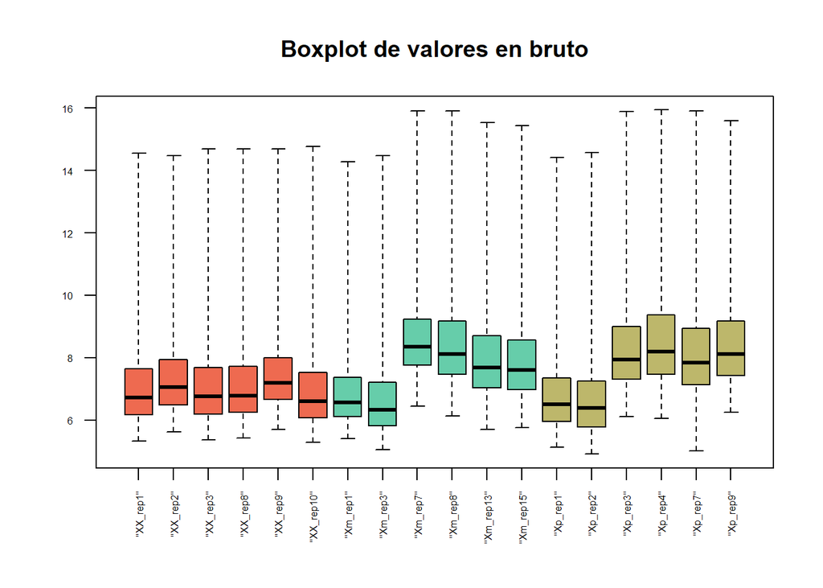

```r
boxplot(rawData, cex.axis=0.5, las=2,
          col = c(rep("coral2", 6), rep("aquamarine3", 6), rep("darkkhaki", 6)),
          main="Boxplot de valores en bruto")
```

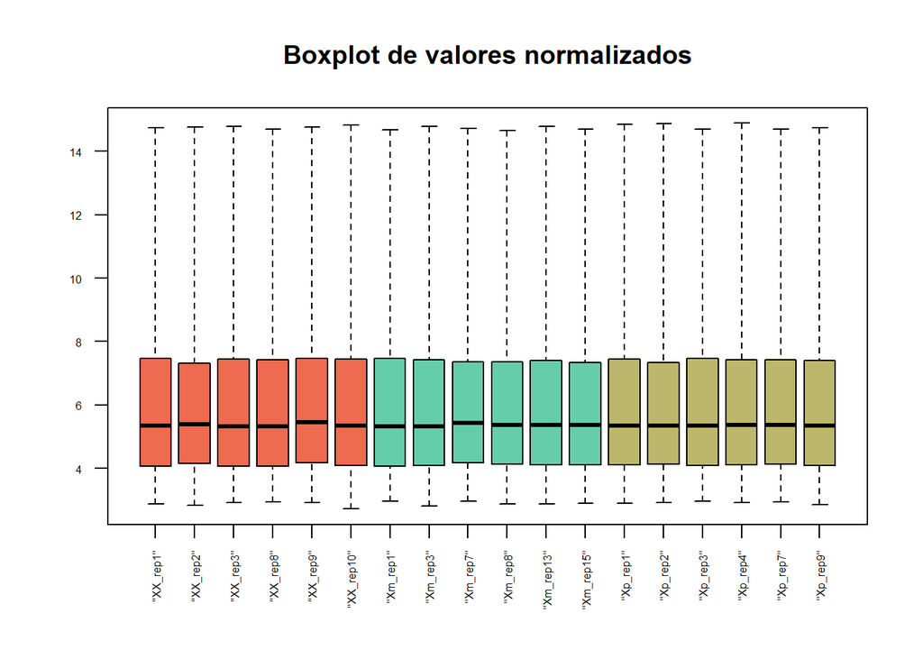

```r
boxplot(eset_rma, cex.axis=0.5, las=2,
          col = c(rep("coral2", 6), rep("aquamarine3", 6), rep("darkkhaki", 6)),
          main="Boxplot de valores normalizados")
```

### **CONTROL DE CALIDAD SOBRE DATOS NORMALIZADOS**

#### **Control de calidad mediante ARRAYQUALITYMETRICS**

```r
library(arrayQualityMetrics)
#arrayQualityMetrics(eset_rma, force=TRUE) # forzamos a que cree de nuevo el directorio con los datos.
```

En esta ocasión podemos hacer más caso a la función ArrayQualityMetrics pero por ejemplo vemos que de los tres métodos de control solo el análisis de DistanceBetweenArrays nos da un **posible oulier** en la muestra etiquetada como **Xm_rep1**, la muestra con síndrome de Turner con cromosoma de origen materno 45Xm. En principio, a menos que aparezca alguna otro dato, no le daremos mucha importancia.

Adjuntamos la tabla:

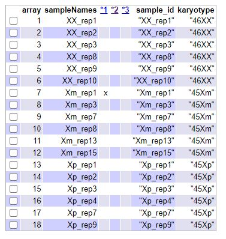

Vamos a seguir el estudio con otros gráficos a ver si obtenemos más claridad en lo que tenemos entre manos.

#### **Estudio de un posible efecto batch**

La verdad es que en este ejemplo, creo que **el efecto batch tiene poco sentido**. Por un lado he podido comprobar que todas las muestras se han tratado al mismo tiempo ya que así se indica en el archivo pData del expresiónSet obtenido mediante getGEO(GSE46687).

Por otra parte el grupo depende del Cariotipo que es un dato que no tiene posible error, no es numérico. O tienes 2 cromosomas XX o no los tienes. No hay temperaturas, no hay tratamientos.

por lo tanto **no le veo el sentido a realizar un estudio de efecto batch**

#### **Control de calidad mediante gráficos de componentes PCA()**

El gráfico de datos normalizados nos permite ver una distribución de las muestras más o menos lógica:

```r
library(ggplot2)
library(ggrepel)

plotPCA3 <- function (datos, labels, factor, title, scale,colores, size = 1.5, glineas = 0.25) {
   data <- prcomp(t(datos),scale=scale)
   # plot adjustments
   dataDf <- data.frame(data$x)
   Group <- factor
   loads <- round(data$sdev^2/sum(data$sdev^2)*100,1)
   # main plot
   p1 <- ggplot(dataDf,aes(x=PC1, y=PC2)) +
     theme_classic() +
     geom_hline(yintercept = 0, color = "gray70") +
     geom_vline(xintercept = 0, color = "gray70") +
     geom_point(aes(color = Group), alpha = 0.55, size = 3) +
     coord_cartesian(xlim = c(min(data$x[,1])-5,max(data$x[,1])+5)) +
     scale_fill_discrete(name = "karyotype")
   # avoiding labels superposition
   p1 + geom_text_repel(aes(y = PC2 + 0.25, label = labels),segment.size = 0.25, size = size) +
     labs(x = c(paste("PC1",loads[1],"%")),y=c(paste("PC2",loads[2],"%"))) +
     ggtitle(paste("Analisis PCA: ",title,sep=" "))+
     theme(plot.title = element_text(hjust = 0.5)) +
     scale_color_manual(values=colores)
   }
```

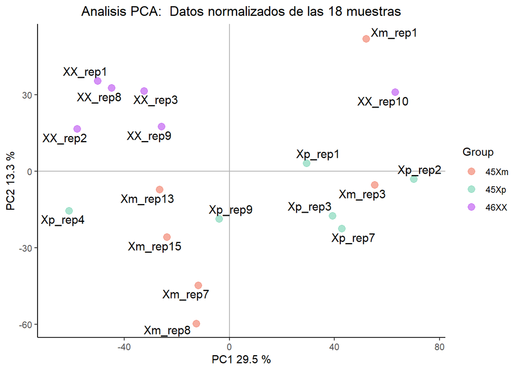

```r
plotPCA3(exprs(eset_rma), labels = targets18$sample_id, factor = targets18$karyotype,
        title="Datos normalizados de las 18 muestras", scale = FALSE, size = 4,
        colores = c("coral2","aquamarine3","darkorchid2"))
```

Si nos fijamos en el cuadro de componentes, vemos que, en esencia, todas las muestras con doble cromosoma XX aparecen en la parte superior del cuadro (variación según el componente PC2) mientras que las muestras con un solo cromosoma están en la parte inferior del cuadro. En cambio, la muestra detectada como outlier mediante ArrayQualityMetrics, **Xm_rep1** aparece arriba de todo, casi fuera del cuadro, en lo que parece una anomalía.

Al aparecer nuevamente esta muestra como posible outlier, me dispongo a realizar un **estudio provisional sin la muestra Xmrep1** y comprobar el mismo gráfico PCA a ver si se notan los cambios.

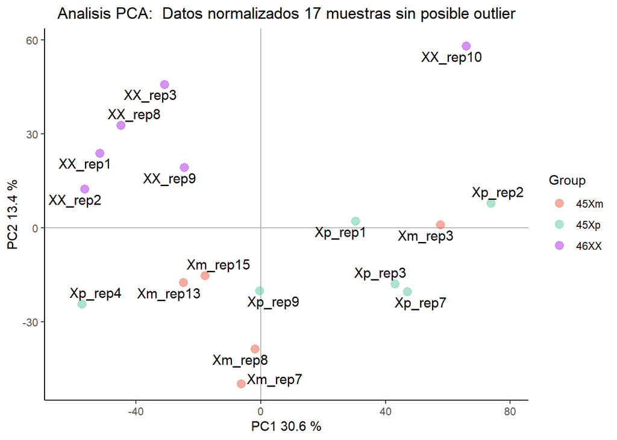

```r
targets17 <- targets18[-7,]
exprs_m17 <- exprs(eset_rma)[,-7]


plotPCA3(exprs_m17, labels = targets17$sample_id, factor = targets17$karyotype,
        title="Datos normalizados 17 muestras sin posible outlier", scale = FALSE, size = 4,
        colores = c("coral2","aquamarine3","darkorchid2"))
```

Aunque tenemos una muestra muy escorada en un extremo, esta vez **XX_rep10**, el cuadro parece más coherente, sobretodo respecto el componente PC2. También se aprecia una tendencia a disponer muestras Xp o Xm en función del componente PC1, a lado y lado del eje vertical, aunque hay muestras que rompen claramente esa distribución.

### **PROCESO DE ANALISIS CON DATOS REVISADOS**

#### **Inicio del estudio con subset de 17 muestras**

Aunque es una decisión que puede tener consecuencias en las conclusiones, decido eliminar la muestra identificada como outlier en ArrayQualityMetrics y corroborada en el gráfico pca.

A partir de aquí voy a montar el expressionset de 17 muestras y a realizar el estudio de expresión génica.

- targets17 <- pData(eset_rma)[-7,]
- exprs_m17 <- exprs(eset_rma)[,-7]
- FenoData <- new(“AnnotatedDataFrame”, data=targets17)
- eset_m17 <- ExpressionSet(assayData = exprs_m17, phenoData=FenoData)

A partir de ahora mis datos están en el expressionSet **eset_m17** Hacemos una previsualización para comprobar que lo hemos realizado correctamente:

```r
targets17 <- pData(eset_rma)[-7,]
exprs_m17 <- exprs(eset_rma)[,-7]
FenoData <- new("AnnotatedDataFrame", data=targets17)
eset_m17 <- ExpressionSet(assayData = exprs_m17, phenoData=FenoData)
knitr::kable(pData(eset_m17), booktabs = TRUE, caption = 'PhenoData del subset de las 17 muestras')
```

PhenoData del subset de las 17 muestras

|  | sample_id | karyotype |
| --- | --- | --- |
| “XX_rep1” | “XX_rep1” | “46XX” |
| “XX_rep2” | “XX_rep2” | “46XX” |
| “XX_rep3” | “XX_rep3” | “46XX” |
| “XX_rep8” | “XX_rep8” | “46XX” |
| “XX_rep9” | “XX_rep9” | “46XX” |
| “XX_rep10” | “XX_rep10” | “46XX” |
| “Xm_rep3” | “Xm_rep3” | “45Xm” |
| “Xm_rep7” | “Xm_rep7” | “45Xm” |
| “Xm_rep8” | “Xm_rep8” | “45Xm” |
| “Xm_rep13” | “Xm_rep13” | “45Xm” |
| “Xm_rep15” | “Xm_rep15” | “45Xm” |
| “Xp_rep1” | “Xp_rep1” | “45Xp” |
| “Xp_rep2” | “Xp_rep2” | “45Xp” |
| “Xp_rep3” | “Xp_rep3” | “45Xp” |
| “Xp_rep4” | “Xp_rep4” | “45Xp” |
| “Xp_rep7” | “Xp_rep7” | “45Xp” |
| “Xp_rep9” | “Xp_rep9” | “45Xp” |

```r
head(exprs(eset_m17)[,1:5],10) #visualizamos los primeros 10 registros de las primeras 4 muestras
```

```
          "XX_rep1" "XX_rep2" "XX_rep3" "XX_rep8" "XX_rep9"
1007_s_at  7.207656  6.905313  6.574902  6.650012  6.661997
1053_at    7.256191  7.079954  7.253400  7.344920  6.990913
117_at     8.753912  8.159330  8.571536  7.731424  8.608466
121_at     7.674366  8.105192  7.688936  7.681396  7.535204
1255_g_at  3.551687  3.515149  3.452685  3.315840  3.437913
1294_at    9.554406  9.279305  9.215286  9.242828  9.347073
1316_at    4.947334  5.042483  4.952601  4.912385  5.264421
1320_at    3.955525  4.141353  4.210289  3.903351  4.527909
1405_i_at 11.358375 11.031041  9.974503 11.709484 11.315969
1431_at    4.146239  4.128431  3.855348  3.694543  4.175387
```

#### **Visualización de porcentaje de genes expresados**

Podemos observar qué porcentage de genes se expresan por encima del umbral del 95% y 99%. La inmensa mayoría de los genes claramente expresados representan menos del 1% del total.

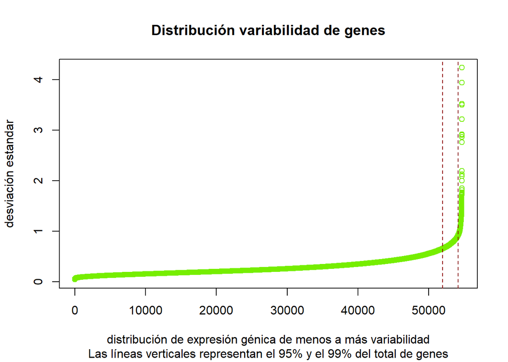

```r
sds <- apply (exprs(eset_m17), 1, sd)
sdsO<- sort(sds)
plot(1:length(sdsO), sdsO, main="Distribución variabilidad de genes",
      sub="Las líneas verticales representan el 95% y el 99% del total de genes",
      xlab="distribución de expresión génica de menos a más variabilidad", ylab="desviación estandar",col="chartreuse2")
abline(v=length(sds)*c(0.95,0.99),col="darkred",lwd = 1,lty = 2)
```

#### **Filtrado de los probes sin valores representativos de expresión**

Podemos hacer algunas pruebas variando el porcentaje de genes que se expresan de forma clara. En concreto visualizamos el 75% y los datos de otros porcentajes:

```r
#BiocManager::install("hgu133plus2.db")
library(genefilter)
library("hgu133plus2.db")
annotation(eset_m17) <- "hgu133plus2.db"


list_filtered <- nsFilter(eset_m17, require.entrez = TRUE, remove.dupEntrez = TRUE, var.filter=TRUE, var.func=IQR, var.cutoff=0.99,filterByQuantile=TRUE, feature.exclude = "^AFFX")
eset_filtered <- list_filtered$eset
#print(list_filtered$filter.log)
#dim(exprs(eset_filtered))

cat("Si aplicamos un filtro del 99% de genes, nos quedan ",dim(exprs(eset_filtered))[1]," probesets")
```

```
Si aplicamos un filtro del 99% de genes, nos quedan  202  probesets
```

```r
list_filtered <- nsFilter(eset_m17, require.entrez = TRUE, remove.dupEntrez = TRUE, var.filter=TRUE, var.func=IQR, var.cutoff=0.95,filterByQuantile=TRUE, feature.exclude = "^AFFX")
eset_filtered <- list_filtered$eset
#print(list_filtered$filter.log)
#dim(exprs(eset_filtered))

cat("Si aplicamos un filtro del 95% de genes, nos quedan ",dim(exprs(eset_filtered))[1]," probesets")
```

```
Si aplicamos un filtro del 95% de genes, nos quedan  1008  probesets
```

```r
list_filtered <- nsFilter(eset_m17, require.entrez = TRUE, remove.dupEntrez = TRUE, var.filter=TRUE, var.func=IQR, var.cutoff=0.75,filterByQuantile=TRUE, feature.exclude = "^AFFX")
eset_filtered <- list_filtered$eset
print(list_filtered$filter.log)
```

```
$numDupsRemoved
[1] 21734

$numLowVar
[1] 15121

$numRemoved.ENTREZID
[1] 12770

$feature.exclude
[1] 10
```

```r
dim(exprs(eset_filtered))
```

```
[1] 5040   17
```

```r
cat("Si aplicamos un filtro del 75% de genes, nos quedan ",dim(exprs(eset_filtered))[1]," probesets")
```

```
Si aplicamos un filtro del 75% de genes, nos quedan  5040  probesets
```

#### **Guardado de archivos en disco**

En esta ocasión vamos a guardar en disco tanto los archivos relacionados con el **eset_rma** como con el **eset_m17**

```r
write.csv(exprs(eset_filtered), file="./results/normalized.Filtered.Data.csv")

write.csv(exprs(eset_rma), file="./results/normalized.Data.csv")
write.csv(exprs(eset_m17), file="./results/normalized17.Data.csv")

save(eset_rma, eset_filtered, file="./results/normalized.Data.Rda")
save(eset_m17, eset_filtered, file="./results/normalized17.Data.Rda")
```

#### **Matriz de contrastes**

En este apartado vamos a construir la matriz de contrastes. En nuestro caso vamos a estudiar dos comparaciones:

- grupo Xp respecto grupo Xm
- grupo Xm respecto grupo XX

```r
if (!exists("eset_filtered")) load (file="./results/normalized17.Data.Rda")
library(limma)
designMat<- model.matrix(~0+karyotype, pData(eset_filtered))
colnames(designMat) <- c("XX", "Xp", "Xm")
print(designMat)
```

[output not shown]

```r
cont.matrix <- makeContrasts(Xp_vs_Xm = Xp-Xm, Xm_vs_XX = Xm-XX,levels=designMat)
print(cont.matrix)
```

```
      Contrasts
Levels Xp_vs_Xm Xm_vs_XX
    XX        0       -1
    Xp        1        0
    Xm       -1        1
```

```r
library(limma)
fit<-lmFit(eset_filtered, designMat)
fit.main<-contrasts.fit(fit, cont.matrix)
fit.main<-eBayes(fit.main)
#class(fit.main)
#colnames(fit.main)
```

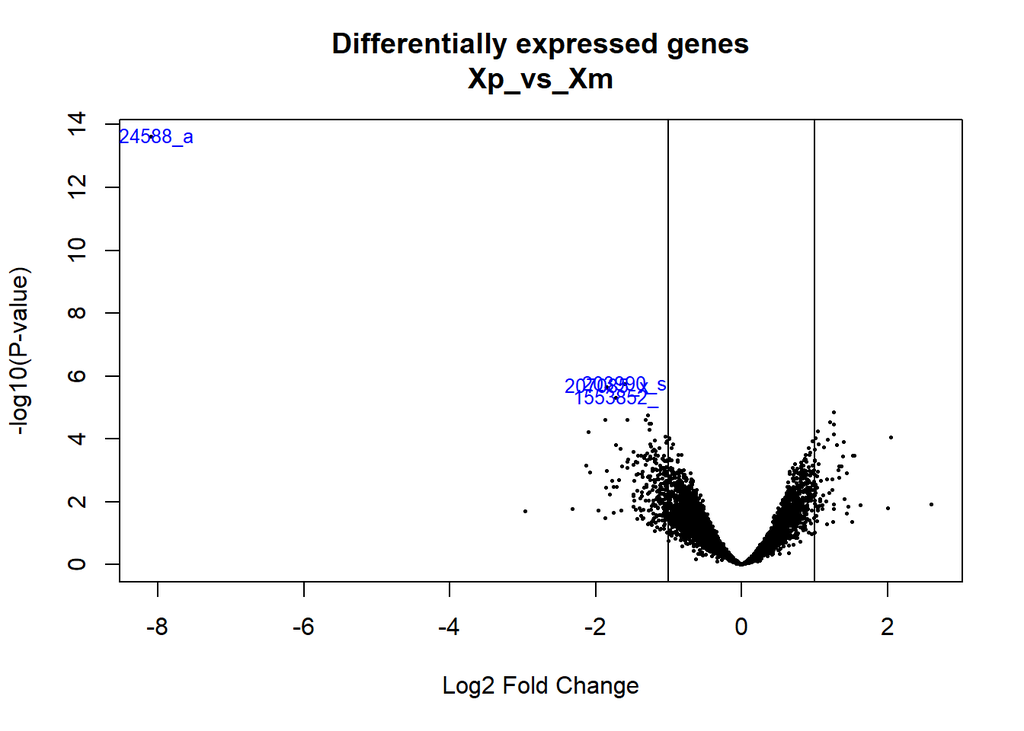

```r
library(hgu133plus2.db)
geneSymbols <- select(hgu133plus2.db, rownames(fit.main), c("SYMBOL"))
SYMBOLS<- geneSymbols$SYMBOL
volcanoplot(fit.main, coef=1, highlight=4, names=rownames(fit.main),
             main=paste("Differentially expressed genes", colnames(cont.matrix)[1], sep="\n"))
abline(v=c(-1,1))
```

Investigamos un poco y vemos que este tránscrito es del tipo XIST (X Inactive Specific Transcript). Se puede consultar en esta página web:

https://genecards.weizmann.ac.il/cgi-bin/geneannot/GA_search.pl?keyword_type=probe_set_id&array=HG-U133&target=genecards&keyword=224588_at

Al tratarse de un transcrito inactivo, me inclino a pensar que hay algun tipo de anomalía y decido apartarlo y ver qué apariencia tiene el mismo gráfico sin dicho probeset. Creamos el nuevo expressionSet sin el probe set **224588_at**. Visualizo los datos de la posición y de las dimensiones del nuevo probeset:

```r
genes <- rownames(exprs(eset_filtered))
pos <- grep('224588',genes) #localizar la posición del transcrito
pos
```

```
[1] 3942
```

```r
genes[pos]
```

```
[1] "224588_at"
```

```r
exprs_f17 <- exprs(eset_filtered)[-pos,]
FenoData <- new("AnnotatedDataFrame", data=targets17)
eset_filtered17 <- ExpressionSet(assayData = exprs_f17, phenoData=FenoData)
dim(exprs(eset_filtered17))
```

```
[1] 5039   17
```

```r
library(limma)
fit<-lmFit(eset_filtered17, designMat)
fit.main<-contrasts.fit(fit, cont.matrix)
fit.main<-eBayes(fit.main)
#class(fit.main)
#colnames(fit.main)
```

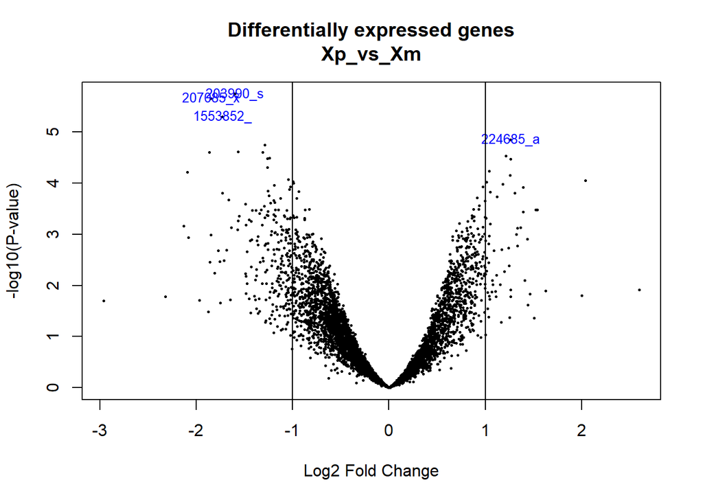

```r
library(hgu133plus2.db)
geneSymbols <- select(hgu133plus2.db, rownames(fit.main), c("SYMBOL"))
SYMBOLS<- geneSymbols$SYMBOL
volcanoplot(fit.main, coef=1, highlight=4, names=rownames(fit.main),
             main=paste("Differentially expressed genes", colnames(cont.matrix)[1], sep="\n"))
abline(v=c(-1,1))
```

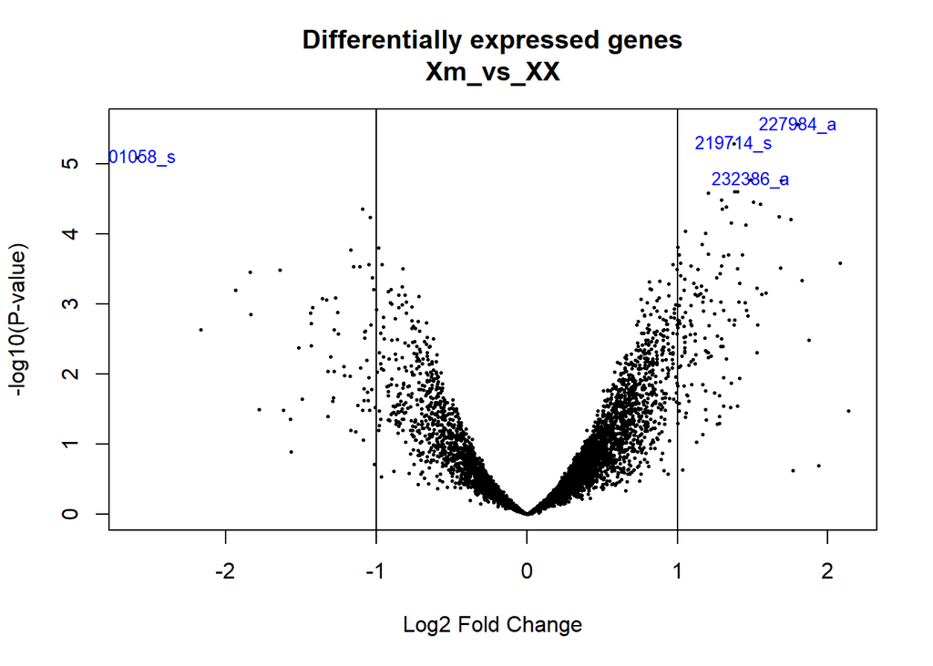

```r
volcanoplot(fit.main, coef=2, highlight=4, names=rownames(fit.main),
             main=paste("Differentially expressed genes", colnames(cont.matrix)[2], sep="\n"))
abline(v=c(-1,1))
```

```r
#volcanoplot(fit.main, coef=3, highlight=4, names=rownames(fit.main),
#             main=paste("Differentially expressed genes", colnames(cont.matrix)[3], sep="\n"))
#abline(v=c(-1,1))
```

```r
res<-decideTests(fit.main, method="separate", adjust.method="fdr", p.value=0.1, lfc=1)

sum.res.rows<-apply(abs(res),1,sum)
res.selected<-res[sum.res.rows!=0,]
print(summary(res))
```

```
       Xp_vs_Xm Xm_vs_XX
Down        181       29
NotSig     4809     4910
Up           49      100
```

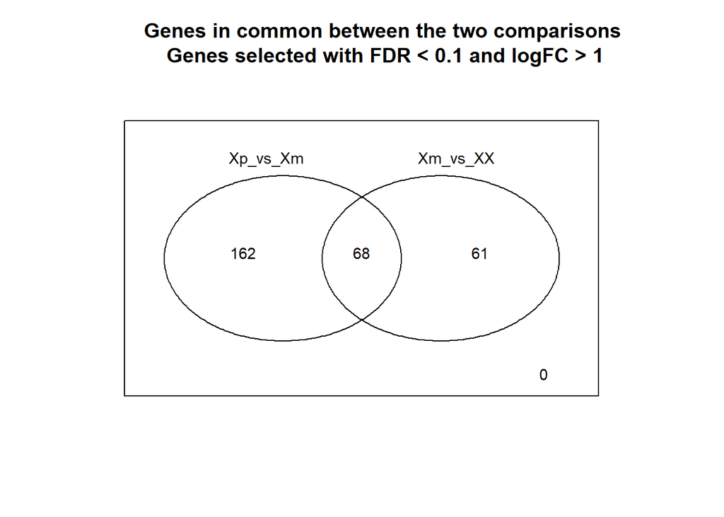

```r
vennDiagram (res.selected[,1:2], cex=0.9)
title("Genes in common between the two comparisons\n Genes selected with FDR < 0.1 and logFC > 1")
```

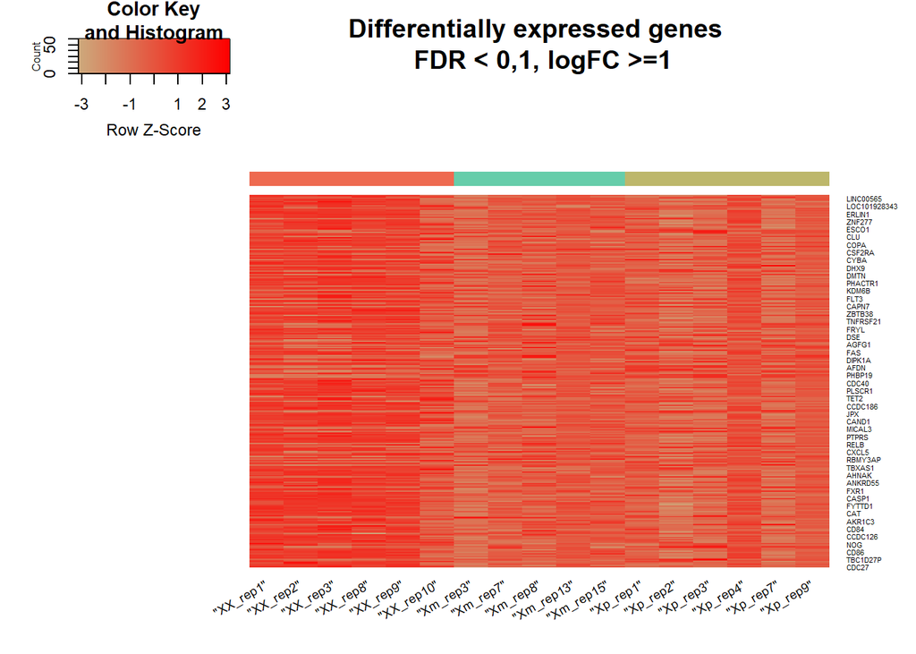

```r
probesInHeatmap <- rownames(res.selected)
#HMdata <- exprs(eset_filtered17)[rownames(exprs(eset_filtered17)) %in% probesInHeatmap,]
HMdata <- exprs(eset_filtered17)[rownames(exprs(eset_filtered17)) %in% probesInHeatmap,]

geneSymbols <- select(hgu133plus2.db, rownames(HMdata), c("SYMBOL"))
SYMBOLS<- geneSymbols$SYMBOL
rownames(HMdata) <- SYMBOLS
write.csv(HMdata, file = file.path("./results/data4Heatmap.csv"))

my_palette <- colorRampPalette(c("burlywood3", "red"))(n = 299)

library(gplots)

heatmap.2(HMdata,
           Rowv = FALSE,
           Colv = FALSE,
           main = "Differentially expressed genes \n FDR < 0,1, logFC >=1",
           scale = "row",
           col = my_palette,
           sepcolor = "cornsilk2",
           sepwidth = c(0.05,0.05),
           cexRow = 0.5,
           cexCol = 0.9,
           key = TRUE,
           keysize = 1.5,
           density.info = "histogram",
           ColSideColors = c(rep("coral2", 6), rep("aquamarine3", 5), rep("darkkhaki", 6)),
           tracecol = NULL,
           dendrogram = "none",
           srtCol = 30)
```

```r
top_Xp_Xm <- topTable (fit.main, number=nrow(fit.main), coef="Xp_vs_Xm", adjust="fdr")
head(top_Xp_Xm)
```

```
                 logFC  AveExpr         t      P.Value   adj.P.Val        B
203990_s_at  -1.598213 6.098201 -6.470658 1.792933e-06 0.005502395 5.059098
207085_x_at  -1.849201 7.669037 -6.383186 2.183923e-06 0.005502395 4.883169
1553852_at   -1.728616 5.704916 -6.021698 4.983776e-06 0.008371083 4.144161
224685_at     1.260529 6.919490  5.576052 1.406439e-05 0.014307776 3.208423
1557100_s_at -1.290304 6.579894 -5.475901 1.780708e-05 0.014307776 2.994738
1558775_s_at -1.567841 6.015776 -5.347557 2.412684e-05 0.014307776 2.719258
```

```r
#top_Xp_XX <- topTable (fit.main, number=nrow(fit.main), coef="Xp_vs_XX", adjust="fdr")
#head(top_Xp_XX)

top_Xm_XX <- topTable (fit.main, number=nrow(fit.main), coef="Xm_vs_XX", adjust="fdr")
head(top_Xm_XX)
```

```
                 logFC  AveExpr         t      P.Value  adj.P.Val        B
227984_at     1.801778 6.682336  6.280811 2.754397e-06 0.01288608 4.665244
219714_s_at   1.373573 8.306174  6.010459 5.114537e-06 0.01288608 4.112094
201058_s_at  -2.588452 8.346349 -5.812259 8.093954e-06 0.01359514 3.700078
232386_at     1.487684 6.994386  5.499934 1.682540e-05 0.01594468 3.040531
1558775_s_at  1.686833 6.015776  5.485663 1.740148e-05 0.01594468 3.010115
203990_s_at   1.382081 6.098201  5.335202 2.484458e-05 0.01594468 2.688046
```

```r
dim(top_Xp_Xm)
```

```
[1] 5039    6
```

```r
# Función para anotar la TopTable
annotatedTopTable <- function(topTab, anotPackage)
{
  topTab <- cbind(PROBEID=rownames(topTab), topTab)
  myProbes <- rownames(topTab)
  thePackage <- eval(parse(text = anotPackage))
  geneAnots <- select(thePackage, myProbes, c("SYMBOL", "ENTREZID", "GENENAME"))
  annotatedTopTab<- merge(x=geneAnots, y=topTab, by.x="PROBEID", by.y="PROBEID")
return(annotatedTopTab)
}

topAnnotated_Xp_vs_Xm <- annotatedTopTable(top_Xp_Xm,
anotPackage="hgu133plus2.db")

#topAnnotated_Xp_vs_XX <- annotatedTopTable(top_Xp_XX,
#anotPackage="hgu133plus2.db")

topAnnotated_Xm_vs_XX <- annotatedTopTable(top_Xm_XX,
anotPackage="hgu133plus2.db")

write.csv(topAnnotated_Xp_vs_Xm, file="./results/topAnnotated_Xp_vs_Xm.csv")
#write.csv(topAnnotated_Xp_vs_XX, file="./results/topAnnotated_Xp_vs_XX.csv")
write.csv(topAnnotated_Xm_vs_XX, file="./results/topAnnotated_Xm_vs_XX.csv")

head(topAnnotated_Xp_vs_Xm,10)
```

```
        PROBEID   SYMBOL ENTREZID
1       1487_at    ESRRA     2101
2    1552258_at    CYTOR   112597
3  1552275_s_at      PXK    54899
4  1552277_a_at  MSANTD3    91283
5  1552287_s_at  AFG3L1P      172
6    1552302_at TMEM106A   113277
7  1552309_a_at     NEXN    91624
8  1552312_a_at    MFAP3     4238
9    1552318_at   GIMAP1   170575
10 1552321_a_at   CCDC65    85478
                                               GENENAME      logFC  AveExpr
1                       estrogen related receptor alpha  0.5991362 8.202485
2                            cytoskeleton regulator RNA  0.4318701 5.512214
3     PX domain containing serine/threonine kinase like -1.1987518 7.352565
```

[output cut: 18 more lines]

```r
#head(topAnnotated_Xp_vs_XX,10)
head(topAnnotated_Xm_vs_XX,10)
```

```
        PROBEID   SYMBOL ENTREZID
1       1487_at    ESRRA     2101
2    1552258_at    CYTOR   112597
3  1552275_s_at      PXK    54899
4  1552277_a_at  MSANTD3    91283
5  1552287_s_at  AFG3L1P      172
6    1552302_at TMEM106A   113277
7  1552309_a_at     NEXN    91624
8  1552312_a_at    MFAP3     4238
9    1552318_at   GIMAP1   170575
10 1552321_a_at   CCDC65    85478
                                               GENENAME       logFC  AveExpr
1                       estrogen related receptor alpha -0.45313745 8.202485
2                            cytoskeleton regulator RNA -0.47226290 5.512214
3     PX domain containing serine/threonine kinase like  0.90985958 7.352565
```

[output cut: 18 more lines]

```r
class(topAnnotated_Xp_vs_Xm)
```

```
[1] "data.frame"
```

```r
dim(topAnnotated_Xp_vs_Xm)
```

```
[1] 5039   10
```

```r
# Nueva lista de genes
listOfTables <- list(Xp_vs_Xm = top_Xp_Xm,
#                     Xp_vs_XX = top_Xp_XX,
                     Xm_vs_XX = top_Xm_XX)
listOfSelected <- list()
for (i in 1:length(listOfTables)){
# select the toptable
topTab <- listOfTables[[i]]
# select the genes to be included in the analysis
whichGenes<-topTab["adj.P.Val"]<0.30
selectedIDs <- rownames(topTab)[whichGenes]
# convert the ID to Entrez
 EntrezIDs<- select(hgu133plus2.db, selectedIDs, c("ENTREZID"))
 EntrezIDs <- EntrezIDs$ENTREZID
 listOfSelected[[i]] <- EntrezIDs
 names(listOfSelected)[i] <- names(listOfTables)[i]
}



sapply(listOfSelected, length)
```

```
Xp_vs_Xm Xm_vs_XX
    2378     1160
```

```r
listOfSelected[[1]]
```

```
   [1] "7403"      "1438"      "157680"    "4301"      "25831"     "8439"
   [7] "996"       "55737"     "49855"     "159013"    "23325"     "489"
  [13] "81553"     "4957"      "23307"     "338440"    "2322"      "10398"
  [19] "293"       "10847"     "8623"      "55367"     "58508"     "10801"
  [25] "55799"     "23524"     "8243"      "1964"      "8226"      "23252"
  [31] "22834"     "100861555" "9934"      "57571"     "2316"      "2330"
  [37] "64231"     "54891"     "54899"     "994"       "944"       "546"
  [43] "84002"     "25865"     "8826"      "55512"     "22820"     "6832"
  [49] "23601"     "3606"      "55454"     "930"       "83548"     "677"
  [55] "10800"     "5782"      "8087"      "3030"      "23135"     "54790"
  [61] "401152"    "942"       "2889"      "9060"      "114799"    "9100"
  [67] "80205"     "25939"     "5442"      "10673"     "54799"     "89848"
  [73] "5359"      "552889"    "51663"     "79974"     "9578"      "85378"
  [79] "81545"     "54832"     "5756"      "57786"     "29940"     "221037"
  [85] "50717"     "22797"     "9644"      "27242"     "79137"     "80162"
```

[output cut: 382 more lines]

```r
listOfSelected[[2]]
```

```
   [1] "64788"     "55799"     "10398"     "54832"     "8439"      "7403"
   [7] "163081"    "2322"      "25831"     "9934"      "157680"    "996"
  [13] "2316"      "23325"     "554203"    "5971"      "54674"     "83481"
  [19] "80205"     "8623"      "159013"    "114799"    "293"       "51643"
  [25] "139189"    "6935"      "57786"     "152137"    "253461"    "546"
  [31] "8243"      "6168"      "124411"    "10847"     "49855"     "9189"
  [37] "121274"    "64593"     "2039"      "54891"     "79137"     "100507303"
  [43] "58508"     "51429"     "57419"     "6374"      "1438"      "54799"
  [49] "130872"    "3718"      "101928343" "23307"     "8226"      "5303"
  [55] "84293"     "8239"      "23279"     "9126"      "10093"     "6916"
  [61] "8874"      "55512"     "326624"    "8242"      "489"       "3674"
  [67] "56252"     "7150"      "10554"     "642236"    "1193"      "83548"
  [73] "22834"     "23601"     "2889"      "1185"      "79814"     "53335"
  [79] "55700"     "152815"    "2766"      "23404"     "149041"    "10443"
  [85] "100131801" "23135"     "9100"      "4863"      "55737"     "54790"
```

[output cut: 179 more lines]

```r
library(org.Hs.eg.db)
mapped_genes2GO <- mappedkeys(org.Hs.egGO)
mapped_genes2KEGG <- mappedkeys(org.Hs.egPATH)
mapped_genes <- union(mapped_genes2GO , mapped_genes2KEGG)
length(mapped_genes)
```

```
[1] 20730
```

```r
#mapped_genes <- as.character(as.integer(substring(mapped_genes,first = 5)))
#head(mapped_genes,20)
```

```r
library(ReactomePA)
library(ggnewscale)

listOfData <- listOfSelected[1:2]
#head(listOfData,10)
names(listOfData)
```

```
[1] "Xp_vs_Xm" "Xm_vs_XX"
```

```r
comparisonsNames <- names(listOfData)
cat("Comparisons!!!")
```

```
Comparisons!!!
```

```r
comparisonsNames
```

```
[1] "Xp_vs_Xm" "Xm_vs_XX"
```

```r
universe <- mapped_genes
for (i in 1:length(listOfData)){
genesIn <- listOfData[[i]]
comparison <- comparisonsNames[i]
enrich.result <- enrichPathway(gene = genesIn,
                                pvalueCutoff = 0.15,
                                readable = T,
                                pAdjustMethod = "BH",
#                                qvalueCutoff = 0.2,
                                organism = "human",
                                universe = universe)
cat("ENRICH ##################################")
head(enrich.result)
cat("##################################")
cat("\nComparison: ", comparison,"\n")
print(head(enrich.result))
}
```

```
ENRICH ####################################################################
Comparison:  Xp_vs_Xm
                         ID
R-HSA-6798695 R-HSA-6798695
R-HSA-983695   R-HSA-983695
R-HSA-983169   R-HSA-983169
R-HSA-4420097 R-HSA-4420097
R-HSA-983705   R-HSA-983705
R-HSA-449147   R-HSA-449147
                                                                                     Description
R-HSA-6798695                                                           Neutrophil degranulation
R-HSA-983695  Antigen activates B Cell Receptor (BCR) leading to generation of second messengers
R-HSA-983169                              Class I MHC mediated antigen processing & presentation
R-HSA-4420097                                                               VEGFA-VEGFR2 Pathway
R-HSA-983705                                              Signaling by the B Cell Receptor (BCR)
R-HSA-449147                                                           Signaling by Interleukins
              GeneRatio   BgRatio       pvalue     p.adjust       qvalue
R-HSA-6798695  123/1428 477/10668 8.965130e-14 1.247050e-10 1.024856e-10
R-HSA-983695    16/1428  32/10668 7.093128e-07 4.933270e-04 4.054283e-04
R-HSA-983169    81/1428 368/10668 2.650661e-06 9.950525e-04 8.177585e-04
R-HSA-4420097   31/1428  99/10668 2.861402e-06 9.950525e-04 8.177585e-04
R-HSA-983705    32/1428 112/10668 1.690094e-05 4.094049e-03 3.364590e-03
R-HSA-449147    93/1428 460/10668 2.044664e-05 4.094049e-03 3.364590e-03
                                                                                                                                                                                                                                                                                                            …
R-HSA-6798695 IQGAP1/CLEC5A/SCAMP1/CPNE1/ATP8B4/FCGR2A/CYBA/ATP11B/CAND1/T…
R-HSA-983695                                                                                                                                                                                                                                                                                                …
R-HSA-983169                                                                                                                                                                                                                                                    HECTD1/CDC27/ZNRF1/UBE2O/RNF19A/TPP2/CYBA/VA…
R-HSA-4420097                                                                                                                                                                                                                                                                                               …
R-HSA-983705                                                                                                                                                                                                                                                                                                …
R-HSA-449147                                                                                                                                                                                CSF2RA/IL18/PTPN12/CD86/RAPGEF1/JAK3/SIGIRR/IL13RA1/AGER/CRE…
              Count
R-HSA-6798695   123
R-HSA-983695     16
R-HSA-983169     81
R-HSA-4420097    31
R-HSA-983705     32
R-HSA-449147     93
ENRICH ####################################################################
Comparison:  Xm_vs_XX
                         ID                                Description
```

[output cut: 12 more lines]

```
R-HSA-114608     19/690 129/10668 6.074986e-04 0.10463854 0.09874510
                                                                                                                                                                                                                           geneID
R-HSA-8939211                                         SMC1A/SMC3/FKBP5/HSP90AA1/PIK3R1/JUND/EGF/USF2/HRAS/CREB1/FOS/AKT3/H2BC11/GNG11/CCNT1/SRC/MED1/H2BC21/GNG2/AKT1/FOSB/JUN/PIK3R3/RAD21/KDM4B/H2BC6/EREG/ZDHHC21/GNAI2/H2BC12
R-HSA-9009391                                                                                                                               HSP90AA1/PIK3R1/EGF/HRAS/CREB1/FOS/AKT3/GNG11/SRC/GNG2/AKT1/PIK3R3/EREG/ZDHHC21/GNAI2
R-HSA-6785807                                                                                                           ZEB1/JAK3/IL18/HSP90AA1/PIK3R1/LCN2/IL4R/RORC/F13A1/HSP90B1/FOS/SOCS3/BCL6/IL6R/AKT1/IL13RA1/CDKN1A/ANXA1
R-HSA-9006931 SMC1A/SMC3/FKBP5/HSP90AA1/NCOR2/PIK3R1/JUND/TBL1XR1/ALDH1A1/…
R-HSA-430116                                                                                                                                                                                              FLNA/GP9/PIK3R1/VWF/SRC
R-HSA-114608                                                                                                           FLNA/ITGA2B/PHACTR2/ITGB3/CLU/TAGLN2/TLN1/ALDOA/PF4/SYTL4/EGF/SPARC/F13A1/VWF/SELP/FAM3C/PPBP/PROS1/SCCPDH
              Count
R-HSA-8939211    30
R-HSA-9009391    15
R-HSA-6785807    18
R-HSA-9006931    36
R-HSA-430116      5
R-HSA-114608     19
```

```r
#if (length(rownames(enrich.result@result)) != 0) {
#write.csv(as.data.frame(enrich.result),
#            file =paste0("./results/","ReactomePA.Results.",comparison,".csv"),
#            row.names = FALSE)
#pdf(file=paste0("./results/","ReactomePABarplot.",comparison,".pdf"))
#print(barplot(enrich.result, showCategory = 15, font.size = 4,
#           title = paste0("Reactome Pathway Analysis for ", comparison,". Barplot")))
#dev.off()
#pdf(file = paste0("./results/","ReactomePAcnetplot.",comparison,".pdf"))
#print(cnetplot(enrich.result, categorySize = "geneNum", schowCategory = 15,
#        vertex.label.cex = 0.75))
#dev.off()
#}
```

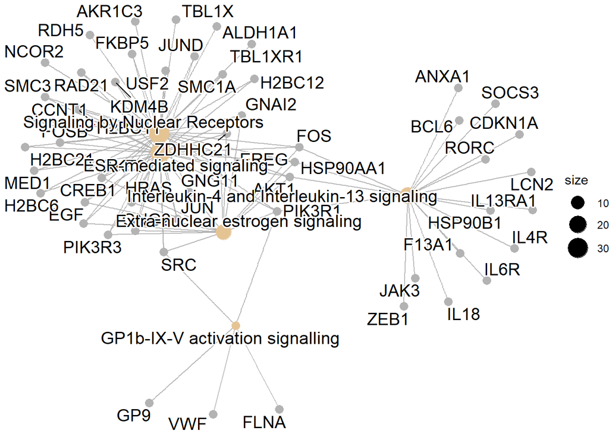

```r
cnetplot(enrich.result, categorySize = "geneNum", schowCategory = 15,
        vertex.label.cex = 0.75)
```

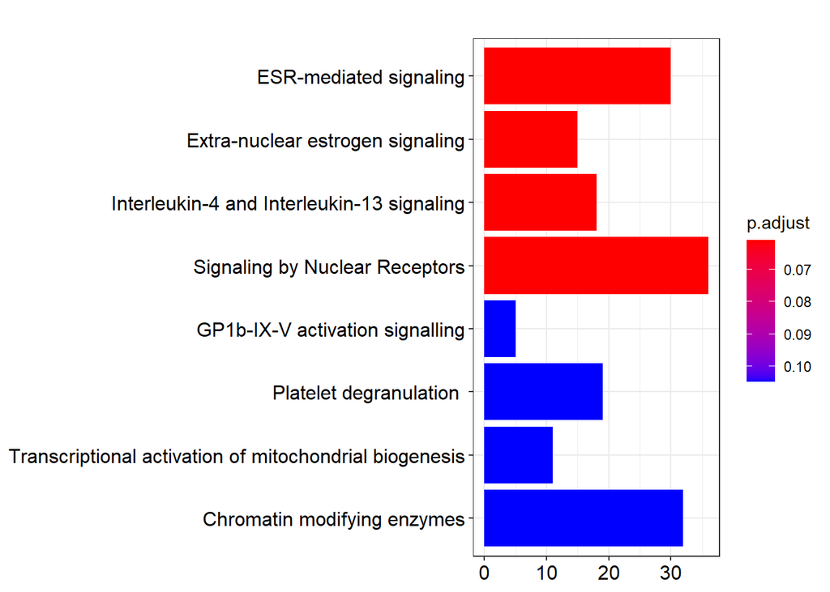

````r
#```

barplot(enrich.result, showCategory=8)
````

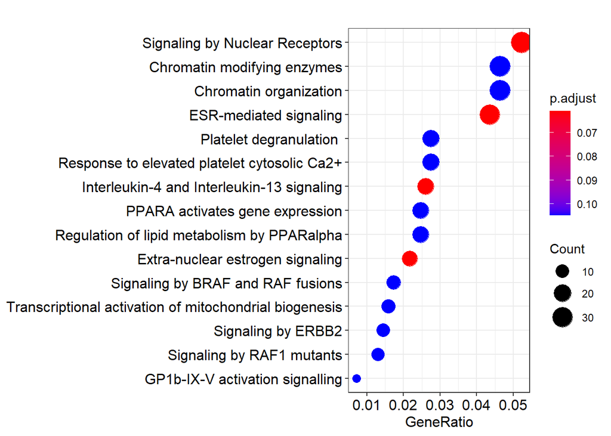

```r
dotplot(enrich.result, showCategory=15)
```

```r
#emapplot(enrich.result)
```

### **CONCLUSIONES (Y PROBLEMAS)**

#### **problemas que no me han permitido llegar a las conclusiones finales**

Por lo tanto mis conclusiones las he ido citando en cada apartado pero no puedo llegar a las conclsuiones finales por falta de resultados.